# Tree Based Methods - Examen

# Classificatieopdracht

Gebruik enkele reeds geziene classifiers en optimalisatietechnieken om een classificatieprobleem via ML op te lossen.

Succes!

```python
%matplotlib inline

import numpy as np
import pandas as pd
import matplotlib.pyplot as plt
import seaborn as sns
from sklearn.model_selection import train_test_split
from sklearn.metrics import classification_report
from sklearn.metrics import confusion_matrix, accuracy_score
from sklearn.preprocessing import OneHotEncoder
from sklearn import preprocessing
from sklearn.preprocessing import LabelEncoder
from sklearn import linear_model
from sklearn.linear_model import LogisticRegression
from scipy.stats import randint
from scipy.stats import uniform
from sklearn.svm import SVC
from sklearn.tree import DecisionTreeClassifier
from sklearn.ensemble import RandomForestClassifier
from sklearn.ensemble import BaggingClassifier
from sklearn.ensemble import AdaBoostClassifier


pd.set_option('display.max_rows',1000)
pd.set_option('display.max_columns',1000)
```

**NASA**  
Gegeven is de dataset **nasa.csv**. Deze dataset bevat gegevens en metingen van waargenomen meteorieten. De bedoeling is om op basis van deze metingen (features) een betrouwbare voorspelling te kunnen doen of een bepaalde meteoriet al dan niet gevaarlijk is - of ze met andere woorden kan inslaan op de aarde. Er wordt een accuracy van minstens 95% geëist.

### Inlezen en preprocessing van de dataset

1. Verwijder de kolommen 'Neo Reference ID', 'Name', 'Orbit ID' ,'Close Approach Date','Epoch Date Close Approach', 'Orbiting Body','Orbit Determination Date' en 'Equinox'
2. Verwijder de samples met ontbrekende waarden volledig (listwise deletion)
3. Vervang de waarden uit de output kolom Hazardous: False / True -> 0 / 1

```python
# Inladen van de dataset
dataset = pd.read_csv("nasa.csv")
dataset.info()
```

```
<class 'pandas.core.frame.DataFrame'>
RangeIndex: 4687 entries, 0 to 4686
Data columns (total 40 columns):
 #   Column                        Non-Null Count  Dtype
---  ------                        --------------  -----
 0   Neo Reference ID              4687 non-null   int64
 1   Name                          4687 non-null   int64
 2   Absolute Magnitude            4687 non-null   float64
 3   Est Dia in KM(min)            4687 non-null   float64
 4   Est Dia in KM(max)            4687 non-null   float64
 5   Est Dia in M(min)             4687 non-null   float64
 6   Est Dia in M(max)             4687 non-null   float64
 7   Est Dia in Miles(min)         4687 non-null   float64
 8   Est Dia in Miles(max)         4687 non-null   float64
 9   Est Dia in Feet(min)          4687 non-null   float64
```

[output cut: 32 more lines]

```python
# Verwijderen van de gevraagde kolommen
cols2drop = ['Neo Reference ID', 'Name', 'Orbit ID' ,'Close Approach Date','Epoch Date Close Approach', 'Orbiting Body','Orbit Determination Date', 'Equinox']
df = dataset.drop(columns=cols2drop)
```

```python
# Vervang de waarden uit de output kolom Hazardous: False / True -> 0 / 1
df.Hazardous = df.Hazardous.astype('Int32')
```

```python
df.Hazardous.sample(5)
```

```
3738    0
1295    1
26      0
786     0
1778    0
Name: Hazardous, dtype: Int32
```

```python
# Verwijderen van samples met ontbrekende waarden
df.isnull().sum().sum()
```

```
np.int64(0)
```

```python
# er zijn blijkbaar geen ontbrekende waarden
df.describe().T
```

|  | count | mean | std | min | 25% | 50% | 75% | max |
| --- | --- | --- | --- | --- | --- | --- | --- | --- |
| Absolute Magnitude | 4687.0 | 22.267865 | 2.890972 | 11.16 | 20.1 | 21.9 | 24.5 | 32.1 |
| Est Dia in KM(min) | 4687.0 | 0.204604 | 0.369573 | 0.001011 | 0.033462 | 0.110804 | 0.253837 | 15.579552 |
| Est Dia in KM(max) | 4687.0 | 0.457509 | 0.826391 | 0.00226 | 0.074824 | 0.247765 | 0.567597 | 34.836938 |
| Est Dia in M(min) | 4687.0 | 204.604203 | 369.573402 | 1.010543 | 33.462237 | 110.803882 | 253.837029 | 15579.552413 |
| Est Dia in M(max) | 4687.0 | 457.508906 | 826.391249 | 2.259644 | 74.823838 | 247.765013 | 567.596853 | 34836.938254 |
| Est Dia in Miles(min) | 4687.0 | 0.127135 | 0.229642 | 0.000628 | 0.020792 | 0.06885 | 0.157727 | 9.680682 |
| Est Dia in Miles(max) | 4687.0 | 0.284283 | 0.513496 | 0.001404 | 0.046493 | 0.153954 | 0.352688 | 21.646663 |
| Est Dia in Feet(min) | 4687.0 | 671.273653 | 1212.511199 | 3.315431 | 109.784247 | 363.529809 | 832.798679 | 51114.018738 |
| Est Dia in Feet(max) | 4687.0 | 1501.013521 | 2711.257465 | 7.41353 | 245.485039 | 812.877364 | 1862.194459 | 114294.420501 |
| Relative Velocity km per sec | 4687.0 | 13.970811 | 7.293223 | 0.335504 | 8.432865 | 12.917889 | 18.077649 | 44.633747 |
| Relative Velocity km per hr | 4687.0 | 50294.919829 | 26255.601377 | 1207.814804 | 30358.31337 | 46504.401181 | 65079.535405 | 160681.487851 |
| Miles per hour | 4687.0 | 31251.307268 | 16314.209644 | 750.489149 | 18863.475327 | 28896.02639 | 40437.89243 | 99841.227826 |
| Miss Dist.(Astronomical) | 4687.0 | 0.256778 | 0.145798 | 0.000178 | 0.13342 | 0.265029 | 0.384154 | 0.499884 |
| Miss Dist.(lunar) | 4687.0 | 99.886706 | 56.715493 | 0.069194 | 51.900211 | 103.096123 | 149.435921 | 194.45491 |
| Miss Dist.(kilometers) | 4687.0 | 38413466.871724 | 21811097.770545 | 26609.886719 | 19959283.0 | 39647712.0 | 57468628.0 | 74781600.0 |
| Miss Dist.(miles) | 4687.0 | 23869021.679287 | 13552787.796487 | 16534.617188 | 12402123.5 | 24635948.0 | 35709350.0 | 46467132.0 |
| Orbit Uncertainity | 4687.0 | 3.516962 | 3.078307 | 0.0 | 0.0 | 3.0 | 6.0 | 9.0 |
| Minimum Orbit Intersection | 4687.0 | 0.08232 | 0.0903 | 0.000002 | 0.014585 | 0.047365 | 0.123593 | 0.477891 |
| Jupiter Tisserand Invariant | 4687.0 | 5.056111 | 1.237818 | 2.196 | 4.0495 | 5.071 | 6.019 | 9.025 |
| Epoch Osculation | 4687.0 | 2457723.608172 | 920.297473 | 2450164.5 | 2458000.5 | 2458000.5 | 2458000.5 | 2458019.5 |
| Eccentricity | 4687.0 | 0.382569 | 0.180444 | 0.007522 | 0.240858 | 0.37245 | 0.512411 | 0.960261 |
| Semi Major Axis | 4687.0 | 1.400264 | 0.524154 | 0.61592 | 1.000635 | 1.240981 | 1.678364 | 5.072008 |
| Inclination | 4687.0 | 13.373844 | 10.936227 | 0.014513 | 4.962341 | 10.311836 | 19.511681 | 75.406667 |
| Asc Node Longitude | 4687.0 | 172.157275 | 103.276777 | 0.001941 | 83.081208 | 172.625393 | 255.026909 | 359.90589 |
| Orbital Period | 4687.0 | 635.582076 | 370.954727 | 176.557161 | 365.605031 | 504.947292 | 794.195972 | 4172.231343 |
| Perihelion Distance | 4687.0 | 0.813383 | 0.242059 | 0.080744 | 0.630834 | 0.833153 | 0.997227 | 1.299832 |
| Perihelion Arg | 4687.0 | 183.932151 | 103.513035 | 0.006918 | 95.625916 | 189.761641 | 271.777557 | 359.993098 |
| Aphelion Dist | 4687.0 | 1.987144 | 0.951519 | 0.803765 | 1.266059 | 1.618195 | 2.451171 | 8.983852 |
| Perihelion Time | 4687.0 | 2457728.108418 | 944.226435 | 2450100.317117 | 2457815.13671 | 2457972.766779 | 2458108.240673 | 2458838.860195 |
| Mean Anomaly | 4687.0 | 181.167927 | 107.501623 | 0.003191 | 87.006918 | 185.718889 | 276.531946 | 359.917991 |
| Mean Motion | 4687.0 | 0.738242 | 0.342627 | 0.086285 | 0.453289 | 0.712946 | 0.984669 | 2.039 |
| Hazardous | 4687.0 | 0.161084 | 0.367647 | 0.0 | 0.0 | 0.0 | 0.0 | 1.0 |

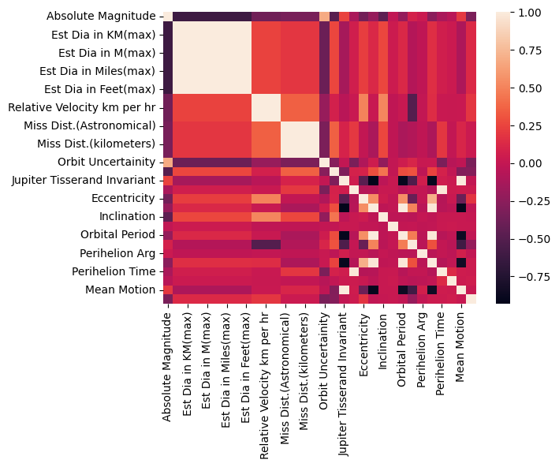

```python
# check gecorreleerde variabelen met een seaborn heatmap
sns.heatmap(df.corr(numeric_only=True));
```

```python
df.columns
```

```
Index(['Absolute Magnitude', 'Est Dia in KM(min)', 'Est Dia in KM(max)',
       'Est Dia in M(min)', 'Est Dia in M(max)', 'Est Dia in Miles(min)',
       'Est Dia in Miles(max)', 'Est Dia in Feet(min)', 'Est Dia in Feet(max)',
       'Relative Velocity km per sec', 'Relative Velocity km per hr',
       'Miles per hour', 'Miss Dist.(Astronomical)', 'Miss Dist.(lunar)',
       'Miss Dist.(kilometers)', 'Miss Dist.(miles)', 'Orbit Uncertainity',
       'Minimum Orbit Intersection', 'Jupiter Tisserand Invariant',
       'Epoch Osculation', 'Eccentricity', 'Semi Major Axis', 'Inclination',
       'Asc Node Longitude', 'Orbital Period', 'Perihelion Distance',
       'Perihelion Arg', 'Aphelion Dist', 'Perihelion Time', 'Mean Anomaly',
       'Mean Motion', 'Hazardous'],
      dtype='object')
```

Vraag: wat zie je in de correlatieplot?

Antwoord: enkele variabelen zijn duidelijk (en ook logisch) sterk gecorreleerd. Dit zijn bv. "Est Dia"'s en "Miss Dist"'s uitgedrukt in verschillende meeteinheiden zoals km en m of miles en feet. De echt significante correlaties liggen in de onderste rechte hoek (behalve de donkerste die sterk negatief gecorreleerd zijn). We kunnen van die dus slechts 1 van de verschillende vars bijhouden voor modelering.

```python
# bereken de correlatie tussen de features in een dataframe.
# Verwijder telkens een van de variabelen die perfect gecoreleerd zijn (correlatie = 1 of -1) om redundantie te vermijden.
# Gebruik hiervoor onderstaande functie.

def drop_perfectly_correlated_features(df, target_col=None, tol=0.1):
    """
    Dropt kolommen die perfect (|corr| == 1) gecorreleerd zijn met een andere kolom.

    - target_col: (optioneel) doelkolom die nooit gedropt wordt
    - tol: tolerantie; gebruik bv. 1e-12 als je floating-point ruis vermoedt
    """
    numeric_df = df.select_dtypes(include=[np.number]).copy()
    protected = {target_col} if (target_col is not None and target_col in numeric_df.columns) else set()

    corr = numeric_df.corr()

    # Bekijk enkel de bovenste driehoek om dubbels te vermijden
    upper = corr.where(np.triu(np.ones(corr.shape), k=1).astype(bool))

    # Kolommen die (bijna) perfect correleren met minstens 1 andere kolom
    if tol == 0.0:
        mask = upper.abs().eq(1.0)
    else:
        mask = np.isclose(upper.abs(), 1.0, atol=tol, rtol=0.0)
        mask = pd.DataFrame(mask, index=upper.index, columns=upper.columns)

    to_drop = []
    for col in upper.columns:
        if col in protected:
            continue
        # Als deze kolom perfect correleert met eender welke eerdere kolom: drop
        if bool(mask[col].fillna(False).any()):
            to_drop.append(col)

    cleaned = df.drop(columns=to_drop, errors="ignore")
    return cleaned, to_drop, corr


# Vul hier je code aan:
df_reduced, dropped_cols, df_corr = drop_perfectly_correlated_features(df)
```

```python
dropped_cols
```

```
['Est Dia in KM(max)',
 'Est Dia in M(min)',
 'Est Dia in M(max)',
 'Est Dia in Miles(min)',
 'Est Dia in Miles(max)',
 'Est Dia in Feet(min)',
 'Est Dia in Feet(max)',
 'Relative Velocity km per hr',
 'Miles per hour',
 'Miss Dist.(lunar)',
 'Miss Dist.(kilometers)',
 'Miss Dist.(miles)',
 'Semi Major Axis',
 'Orbital Period',
 'Aphelion Dist',
 'Perihelion Time',
 'Mean Motion']
```

Maak nu opnieuw de correlatieplot en rond de decimalen af to op 2 cijfers na de komma voor leesbaarheid.

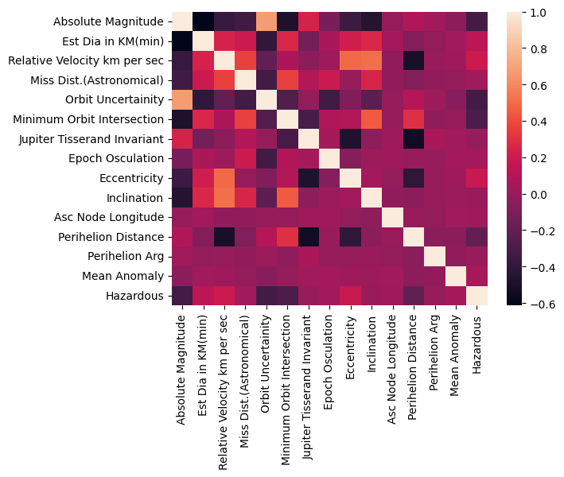

```python
sns.heatmap(df_reduced.corr(numeric_only=True));
```

Controleer of de dataset al dan niet **gebalanceerd** is. **Antwoord** duidelijk of dit al dan niet het geval is en wat de **mogelijke gevolgen** kunnen zijn mocht deze niet gebalanceerd zijn.

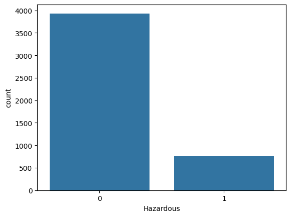

```python
# Controleer of de dataset gebalanceerd is.
sns.countplot(data=df,x='Hazardous');
```

```python
df.Hazardous.value_counts(normalize=True) * 100
```

```
Hazardous
0    83.891615
1    16.108385
Name: proportion, dtype: Float64
```

```python
# Antwoord: De dataset lijkt niet echt gebalanceerd te zijn. Slechts 16 % is gevaarlijk, en bijna 84 % niet.
```

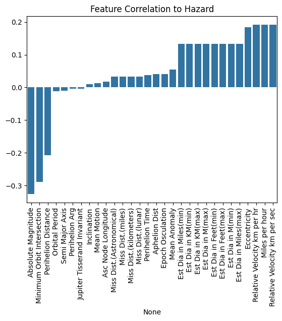

```python
# een andere manier om te checken welke features zijn het meest gecorr met al dan niet gevaarlijk
rel_of_interest = df_corr.Hazardous.sort_values().iloc[1:-1]
sns.barplot(x=rel_of_interest.index,y=rel_of_interest.values)
plt.title("Feature Correlation to Hazard")
plt.xticks(rotation=90);
```

## DEEL 1: UNSUPERVISED LEARNING

Stel dat NASA geen gegevens heeft over welke asteroïden gevaarlijk zijn (verwijder dus de kolom "Hazardous" uit de data). NASA wil groepen in de data vinden. Voer KMeans-clustering uit en bepaal het beste aantal clusters (tussen 2 en 30) op basis van de silhouette score en bijhorende silhouette plots.

Vraag A: Wat is het optimale aantal clusters op basis van deze silhouette technieken?

Vraag B: Is er een andere manier om het beste aantal clusters voor je KMeans-algoritme te bepalen? Zo ja, wat kun je uit dat resultaat afleiden?

```python
# --- Unsupervised: StandardScaler + KMeans (k kiezen met silhouette) ---
from sklearn.cluster import KMeans
from sklearn.preprocessing import StandardScaler
scaler = StandardScaler()
```

```python
feature_cols = [c for c in df_reduced.columns if c != 'Hazardous']
X = df_reduced[feature_cols].copy()
X = X.apply(pd.to_numeric, errors='coerce')
print('Missing values after numeric conversion:', X.isnull().sum().sum())
```

```
Missing values after numeric conversion: 0
```

```python
X_scaled = scaler.fit_transform(X)
X_scaled.shape
```

```
(4687, 14)
```

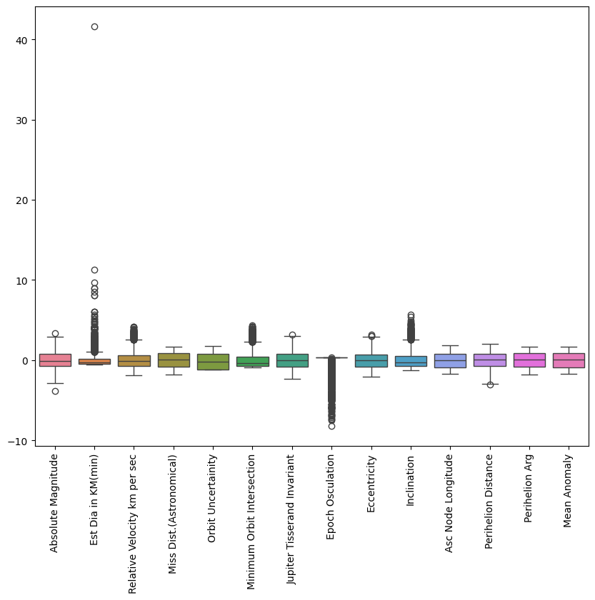

```python
# even checken voor outliers (met feat names erbij)
X_scaled_df = pd.DataFrame(X_scaled, columns=feature_cols)

plt.figure(figsize=(10, 8))
sns.boxplot(data=X_scaled_df)
plt.xticks(rotation=90)
plt.show()
```

```python
# Est Dia in KM en Epoch Osculation gaan waarsch K-means kapot maken (omdat die zal proberen alle outliers bij een of ander cluster te klasseren). DBScan zou die anomaliers beter handelen...
```

```python
from sklearn.metrics import silhouette_score, silhouette_samples
import matplotlib.cm as cm

# Silhouette plots hulpfunctie die je kan gebruiken indien nodig:
def plot_silhouette(X, n_clusters):
    kmeans = KMeans(n_clusters=n_clusters, random_state=0, n_init=10)
    cluster_labels = kmeans.fit_predict(X)

    silhouette_avg = silhouette_score(X, cluster_labels)
    sample_silhouette_values = silhouette_samples(X, cluster_labels)

    fig, ax = plt.subplots(1, 1, figsize=(7, 4))
    ax.set_xlim([-0.1, 1.0])
    ax.set_ylim([0, len(X) + (n_clusters + 1) * 10])

    y_lower = 10
    for i in range(n_clusters):
        ith_cluster_silhouette_values = sample_silhouette_values[cluster_labels == i]
        ith_cluster_silhouette_values.sort()

        size_cluster_i = ith_cluster_silhouette_values.shape[0]
        y_upper = y_lower + size_cluster_i

        color = cm.nipy_spectral(float(i) / n_clusters)
        ax.fill_betweenx(
            np.arange(y_lower, y_upper),
            0,
            ith_cluster_silhouette_values,
            facecolor=color,
            edgecolor=color,
            alpha=0.7,
        )
        ax.text(-0.05, y_lower + 0.5 * size_cluster_i, str(i))
        y_lower = y_upper + 10

    ax.axvline(x=silhouette_avg, color="red", linestyle="--", linewidth=1)
    ax.set_title(f"Silhouette plot (k={n_clusters}) | avg={silhouette_avg:.3f}")
    ax.set_xlabel("Silhouette coefficient")
    ax.set_ylabel("Cluster")
    ax.set_yticks([])
    plt.tight_layout()
    plt.show()
```

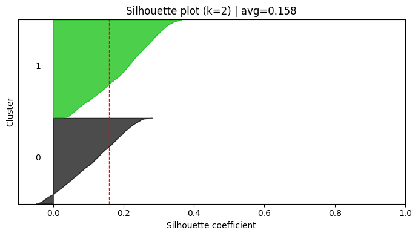

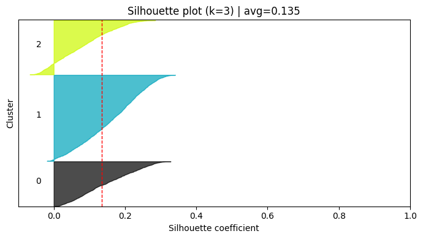

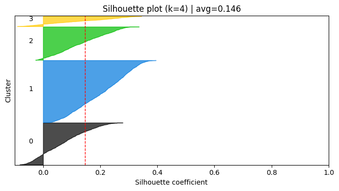

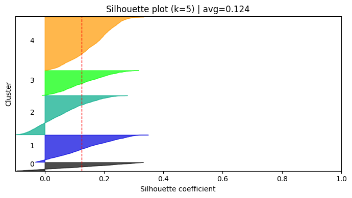

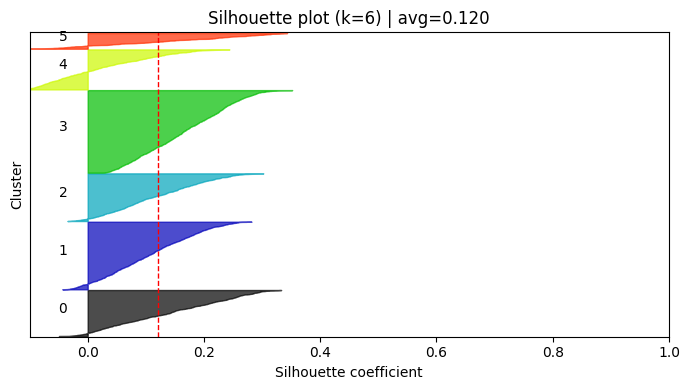

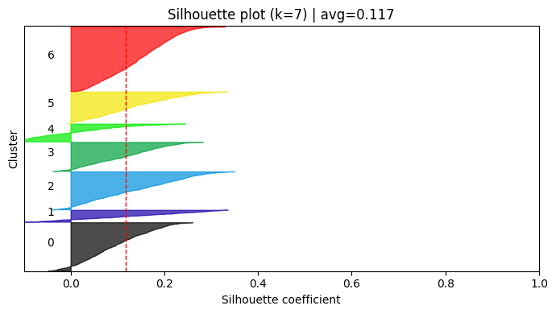

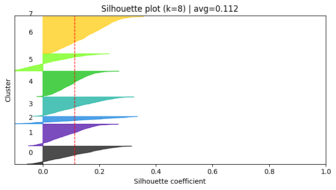

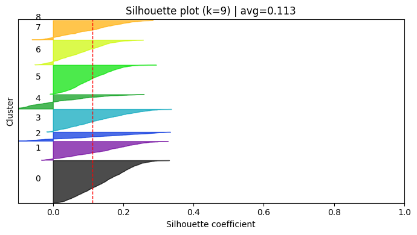

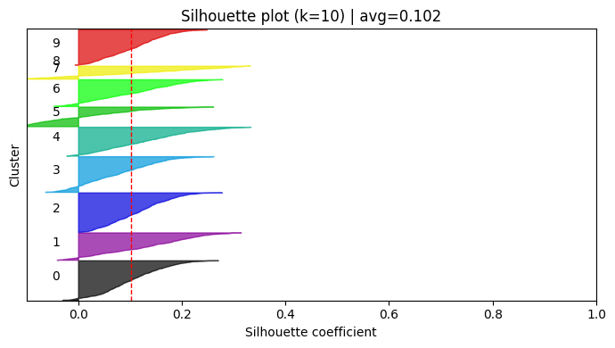

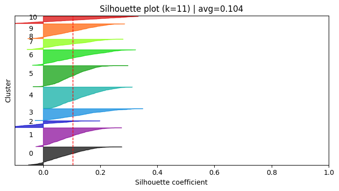

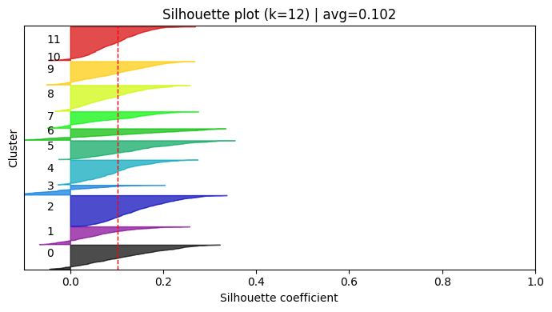

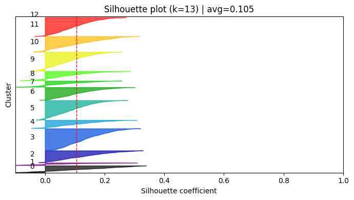

[16 more figures not shown]

```python
k_values = list(range(2, 30))

# train hier je KMeans modellen en bereken o.a de silhouette scores voor elke k:
for k in k_values:
    plot_silhouette(X_scaled, k)
```